# Predicting Oral Points of Departure (Preliminary): LCIA QSAR Project

**Author:** Jacob Kvasnicka  
**Date:** March 7, 2023

This notebook implements a preliminary Random Forest pipeline to predict `oral points of departure` for the LCIA QSAR Project for `non-reproductive/developmental effects`. This analysis consists of the following main sections:

1. Use the original feature set of 12 physical-chemical property estimates by Nicolò Aurisano.
2. Use a larger set of 226 features including updated physical-chemical property estimates from CompTox, and molecular descriptors from the RDKit Python library. For the updated property estimates, some implausible predicted values are filtered out (e.g., negative water solubility). Use the median experimental value across all data sources, if present, else use the median predicted value.
3. Assess the relevance of these new features using a permutation approach.

For the Random Forest, a similar approach is used as Nicolò Aurisano with the following notable differences in this analysis:

1. Filter out chemicals that are inappropriate for QSAR modeling:
   - Drop any chemicals missing a molecular formula or DTXSID (e.g., minerals, mixtures, etc.)
   - Drop any chemicals that contain metal.

As was done by Nicolò Aurisano, exclude any chemicals with study count <= 3.

1. Implement a feature preprocessing pipeline:
   1. Drop constant features
   2. Drop features with missing values exceeding threshold % (10% default)
   3. Impute missing values with medians
   4. Remove strong correlations among features (default > 0.9, Pearson)
2. Implement 1-fold validation (80/20% train/test) while accepting default hyperparameter values. Later, can improve.

```python
import pandas as pd
import numpy as np
from os import path
from sklearn.model_selection import train_test_split
from sklearn.ensemble import RandomForestRegressor
from sklearn.inspection import permutation_importance
import matplotlib.pyplot as plt
import input_output, features, parse
```

## Define some global parameters and functions

```python
effect_type = 'non-reproductive/developmental effects'
exposure_route = 'oral'
target_variable = 'POD [mg/kg-d]'

# Helper function for plotting.
count_features = lambda results: str(len(results['X_test'].columns))
```

Random forests require relatively minimal feature preprocessing. As a first pass, the following preprocessing pipeline is used.

```python
def features_preprocessing_pipeline(
        X_train, X_test, missing_thres=0.1, corr_thres=0.9,
        corr_method=None):
    '''
    '''
    if corr_method is None:
        corr_method = 'pearson'

    # Drop constant features.
    const_columns = features.constant_columns(X_train)
    X_train = X_train.drop(const_columns, axis=1)
    X_test = X_test.drop(const_columns, axis=1)

    # Drop features with proportions of missing values > threshold.
    missing_columns = features.columns_missing_exceeding(
        X_train, missing_thres)
    X_train = X_train.drop(missing_columns, axis=1)
    X_test = X_test.drop(missing_columns, axis=1)

    # For all features, impute missing values with the medians.
    medians = X_train.quantile(0.5)
    X_train = X_train.fillna(medians)
    X_test = X_test.fillna(medians)

    # Remove strong correlations among the features.
    corr_columns = features.correlated_columns(
        X_train, corr_thres, corr_method)
    X_train = X_train.drop(corr_columns, axis=1)
    X_test = X_test.drop(corr_columns, axis=1)

    return X_train, X_test
```

As a first pass, a 1-fold validation will be used. The data are randomly split into separate training (80%) and test (20%) sets. The default hyperparameter values will be accepted for now, which may lead to some overfitting. Later, these hyperparameters could be tuned using a grid-search algorithm.

```python
def random_forest_regression_pipeline(
        X, y, test_size=0.2, random_state=1):
    '''
    '''
    # Get the intersection of chemicals.
    X, y = features.inner_join_split(X, y)

    X_train, X_test, y_train, y_test = train_test_split(
        X,
        y,
        test_size=test_size,
        random_state=random_state)

    X_train, X_test = features_preprocessing_pipeline(
        X_train, X_test)

    estimator = RandomForestRegressor(
        n_jobs=-1,
        random_state=random_state)
    estimator.fit(X_train, y_train)
    y_pred = estimator.predict(X_test)

    results = {
        'X_train': X_train,
        'X_test': X_test,
        'y_train': y_train,
        'y_test': y_test,
        'estimator': estimator,
        'y_pred': y_pred }

    return  results
```

```python
def plot_model_evaluation(
        X_test, y_test, y_pred, estimator, title, **kwargs):
    '''Helper function to plot regression from a results dictionary.
    '''
    score = '$R^2$ = ' + str(estimator.score(X_test, y_test).round(2))
    xlabel = 'Predicted log10(POD [mg/kg-d]'
    ylabel = 'Actual log10(POD [mg/kg-d]'

    fig, ax = plot_regression(
        y_pred,
        y_test,
        score,
        title,
        xlabel,
        ylabel)

    return fig, ax

def plot_regression(
        x, y, score, title=None, xlabel=None, ylabel=None):
    '''
    '''
    fig, ax = plt.subplots()

    ax.scatter(
        x,
        y,
        color='black')

    # Plot the one-one line for comparison.
    ax.plot(
        y,
        y,
        color='red',
        linestyle='--',
        linewidth=0.75)

    bbox = dict(
        boxstyle='round',
        fc='blanchedalmond',
        ec='orange',
        alpha=0.5
    )
    text_position = (0.95, 0.07)
    ax.text(
        *text_position,
        score,
        fontsize=10,
        bbox=bbox,
        transform=ax.transAxes,
        horizontalalignment='right')

    ax.set_title(title)
    ax.set_xlabel(xlabel)
    ax.set_ylabel(ylabel)

    return fig, ax
```

## Load & parse the data

### Target variable: Point of departure [mg/kg-d]

Load the toxicity data and any exclude chemicals with study count <= 3, following Nicolò Aurisano (R script, *RF BMD25 ALL*).

```python
tox_data_path = path.join(
    'Source',
    'TOX_data_Nicolo_final_v01b.xlsx')

# Define key-word arguments for pandas.read_excel().
kwargs = {
    'sheet_name': exposure_route.upper(),
    'header': [0, 1]}

raw_tox_data = (
    pd.read_excel(tox_data_path, **kwargs))

chem_identifiers = (
    raw_tox_data
    .swaplevel(axis=1)
    [['casrn', 'dtxsid']]
    .droplevel(-1, axis=1))
uppercase_mapping = {
    k: k.upper() for k in chem_identifiers.keys()}
chem_identifiers = chem_identifiers.rename(
    uppercase_mapping, axis=1)

tox_data = (
    raw_tox_data
    .swaplevel(axis=1)
    [[target_variable, 'count']]
    .swaplevel(axis=1))
tox_data.index = chem_identifiers['DTXSID']

tox_data
```

| DTXSID | non-reproductive/developmental effects POD [mg/kg-d] | reproductive/developmental effects POD [mg/kg-d] | non-reproductive/developmental effects count | reproductive/developmental effects count |
| --- | --- | --- | --- | --- |
| DTXSID5020281 | 0.079675 | 0.354124 | 23.0 | 47.0 |
| DTXSID8020961 | 0.586497 | 40.438400 | 19.0 | 11.0 |
| DTXSID0021834 | NaN | 33.480792 | NaN | 2.0 |
| DTXSID3032622 | 14.768933 | 14.380317 | 1.0 | 2.0 |
| DTXSID2044347 | NaN | 51.561597 | NaN | 2.0 |
| ... | ... | ... | ... | ... |
| NODTXSID_NOCAS_Zeolite, synthetic, cryst | 104.698063 | NaN | 2.0 | NaN |
| NODTXSID_NOCAS_zinc 2-hydroxy-5-(C13-C18 | 191.151635 | NaN | 1.0 | NaN |
| NODTXSID_NOCAS_Zyclen | 191.151635 | NaN | 1.0 | NaN |
| NODTXSID_RN: 2778-42-9 | NaN | 28.823809 | NaN | 2.0 |
| NODTXSID_-00-000 | 55.701587 | NaN | 1.0 | NaN |

10155 rows × 4 columns

```python
# Apply the same filter as Nicolo.
tox_data_sub = tox_data[effect_type]
where_sufficient_count = tox_data_sub['count'] > 3
chemicals_to_keep = where_sufficient_count

tox_data_sub = tox_data_sub.loc[chemicals_to_keep]
log10_pods = np.log10(tox_data_sub[target_variable])

log10_pods
```

```
DTXSID
DTXSID5020281                              -1.098677
DTXSID8020961                              -0.231734
DTXSID7030698                               3.472003
DTXSID2026652                               1.042817
DTXSID6026080                               1.842616
                                              ...
NODTXSID_NOCAS_Vanadium carbide nitride    -0.187338
NODTXSID_NOCAS_vanadyl pyrophosphate        1.551173
NODTXSID_NOCAS_Vinasses, residue of ferm    3.107675
NODTXSID_NOCAS_Yellow pigment additive      1.305606
NODTXSID_NOCAS_Zeolite, cuboidal, crysta    2.019939
Name: POD [mg/kg-d], Length: 2806, dtype: float64
```

### Original feature set: Physical-chemical properties

Use the original set of 12 physical-chemical property estimates by Nicolò Aurisano (R script, *RF BMD25 ALL*).

Exclude any chemicals for which all feature values are missing.

```python
original_features_path = path.join(
    'Source',
    'Input_ALL_V01a.xlsx')

# Define key-word arguments for pandas.read_excel().
kwargs = {
    'sheet_name': 'data',
    'header': 0}

feature_names = [
    'ATM_O',
    'BIOC_O',
    'BIOD_O',
    'BP_O',
    'HL_O',
    'KM_O',
    'LOGKOA_O',
    'KOC_O',
    'LOGP_O',
    'MP_O',
    'VP_O',
    'WS_O']

original_features = (
    pd.read_excel(original_features_path, **kwargs)
    .set_index('CAS_CORRECTED')
    .join(
        chem_identifiers.set_index('CASRN'),
        how='inner')
    .set_index('DTXSID')
    [feature_names])

# Drop duplicated rows.
original_features = original_features.drop_duplicates()

# To avoid any redudant logarithmic transformations.
# log_columns = ['LOGKOA_O', 'LOGP_O']
# features.log10_inverse_transform(original_features, log_columns)

original_features
```

| DTXSID | ATM_O | BIOC_O | BIOD_O | BP_O | HL_O | KM_O | LOGKOA_O | KOC_O | LOGP_O | MP_O | VP_O | WS_O |
| --- | --- | --- | --- | --- | --- | --- | --- | --- | --- | --- | --- | --- |
| DTXSID5020281 | 7.429490e-13 | 20.11010 | 4.84081 | 242.050 | 4.947790e-06 | 0.332365 | 4.32722 | 507.6930 | 2.39154 | 82.9942 | 2.203470e-02 | 1.317610e-03 |
| DTXSID8020961 | 1.480110e-12 | 3.47311 | 6.64833 | 331.672 | 1.265030e-09 | 0.306715 | 6.57226 | 75.9962 | 1.38804 | 145.5400 | 3.265100e-06 | 4.815930e-03 |
| DTXSID0021834 | 1.155450e-12 | 11.35610 | 4.09570 | 278.910 | 4.207650e-10 | 0.251436 | 6.11321 | 233.1200 | 1.91211 | 113.5640 | 9.970590e-05 | 9.679290e-02 |
| DTXSID2044347 | 7.147800e-12 | 7.55058 | 4.91679 | 248.981 | 9.683370e-08 | 0.279812 | 5.07316 | 98.5113 | 1.74292 | 37.4772 | 6.500820e-03 | 1.201570e-02 |
| DTXSID9059204 | 1.280200e-11 | 12.93020 | 4.52465 | 262.457 | 8.829520e-08 | 0.318916 | 5.78333 | 109.5910 | 2.32425 | 24.6003 | 9.898050e-03 | 4.557770e-03 |
| ... | ... | ... | ... | ... | ... | ... | ... | ... | ... | ... | ... | ... |
| DTXSID6057879 | 2.014600e-11 | 20.26340 | 6.00889 | 417.425 | 1.882080e-07 | 1.137960 | 10.52190 | 881.4960 | 3.72958 | 181.8440 | 1.564390e-08 | 4.541010e-07 |
| DTXSID5057880 | 1.382820e-11 | 96.57770 | 3.35362 | 415.812 | 2.941970e-07 | 1.655430 | 10.64380 | 961.6230 | 2.95065 | 125.4470 | 6.420140e-08 | 5.643740e-07 |
| DTXSID5057882 | 1.594230e-11 | 225.96200 | 3.54031 | 337.893 | 2.333810e-07 | 3.627750 | 10.62620 | 8156.8700 | 3.84550 | 161.2890 | 2.468280e-07 | 1.982760e-06 |
| DTXSID5057884 | 2.432130e-11 | 82.99380 | 6.80176 | 375.225 | 1.494930e-10 | 0.148214 | 9.54575 | 2186.0300 | 2.90792 | 181.9450 | 1.335850e-09 | 3.015700e-05 |
| DTXSID0057885 | 2.491050e-11 | 19.04870 | 5.27344 | 346.531 | 6.479200e-10 | 1.686170 | 9.67654 | 161483.0000 | 5.49079 | 168.4210 | 2.338530e-09 | 3.245060e-08 |

3913 rows × 12 columns

### New feature set: 226 physical-Chemical properties & molecular descriptors

- Updated physical-chemical properties from CompTox Chemistry Dashboard
- 2D molecular descriptors from RDKit Python library

```python
features_dir = 'Features'

file_for_features = {
    'properties': 'physical-chemical-properties.csv',
    'descriptors': 'molecular-descriptors.csv'}

index_col = 'DTXSID'

# NOTE: inner join preserves dtype if any NaN.
new_features = input_output.read_csv_files(
    features_dir,
    file_for_features.values(),
    index_col=index_col)
new_features = pd.concat(
    new_features, axis=1, join='inner')

# To avoid any redudant logarithmic transformations.
# log_columns = [c for c in new_features.columns if 'Log' in c]
# features.log10_inverse_transform(new_features, log_columns)

new_features
```

| DTXSID | Boiling Point | LogKow: Octanol-Water | Melting Point | Vapor Pressure | Water Solubility | pKa Acidic Apparent | pKa Basic Apparent | Henry's Law | LogKoa: Octanol-Air | Density | ... | fr_sulfide | fr_sulfonamd | fr_sulfone | fr_term_acetylene | fr_tetrazole | fr_thiazole | fr_thiocyan | fr_thiophene | fr_unbrch_alkane | fr_urea |
| --- | --- | --- | --- | --- | --- | --- | --- | --- | --- | --- | --- | --- | --- | --- | --- | --- | --- | --- | --- | --- | --- |
| DTXSID001004378 | 250.1615 | 4.57300 | -6.74517 | 3.028880e-02 | 3.500037 | NaN | NaN | 1.779640e-04 | 5.79940 | 0.9360 | ... | 0 | 0 | 0 | 0 | 0 | 0 | 0 | 0 | 0 | 0 |
| DTXSID001005033 | 433.2565 | 7.83500 | -12.77820 | 4.497950e-07 | 3.500005 | NaN | NaN | 3.093680e-07 | 11.55540 | 0.9590 | ... | 0 | 0 | 0 | 0 | 0 | 0 | 0 | 0 | 0 | 0 |
| DTXSID001006300 | 403.8065 | 2.85500 | 157.42100 | 1.085070e-07 | 1.910402 | NaN | NaN | 3.260260e-10 | 8.19567 | 0.9780 | ... | 0 | 0 | 0 | 0 | 0 | 0 | 0 | 0 | 3 | 0 |
| DTXSID001014636 | 316.3100 | -6.38000 | 135.81500 | 1.007590e-05 | 0.479421 | NaN | NaN | 6.082690e-08 | 8.69471 | NaN | ... | 0 | 0 | 0 | 0 | 0 | 0 | 0 | 0 | 0 | 0 |
| DTXSID00160734 | 370.6550 | -3.51600 | 234.01700 | 1.324465e-11 | 2.383000 | NaN | NaN | 1.347040e-11 | 9.51657 | 1.8395 | ... | 0 | 0 | 0 | 0 | 0 | 0 | 0 | 0 | 0 | 0 |
| ... | ... | ... | ... | ... | ... | ... | ... | ... | ... | ... | ... | ... | ... | ... | ... | ... | ... | ... | ... | ... | ... |
| DTXSID90904366 | 350.8880 | 1.20645 | 167.58800 | 8.160880e-09 | 0.000007 | NaN | NaN | 7.376670e-09 | 11.68410 | NaN | ... | 0 | 0 | 0 | 0 | 0 | 0 | 0 | 0 | 0 | 0 |
| DTXSID90961393 | 367.1445 | 1.92900 | 136.97800 | 2.155190e-06 | 3.500798 | NaN | NaN | 1.424060e-09 | 8.19610 | 1.0910 | ... | 0 | 0 | 0 | 0 | 0 | 0 | 0 | 0 | 0 | 0 |
| DTXSID90965533 | 328.7040 | 7.13291 | 3.52433 | 1.120285e-04 | 3.500003 | NaN | NaN | 1.939980e-07 | 8.48610 | 0.8950 | ... | 0 | 0 | 0 | 0 | 0 | 0 | 0 | 0 | 1 | 0 |
| DTXSID90990466 | 363.0410 | -1.24400 | 239.74000 | 8.409810e-09 | 0.744224 | NaN | NaN | 1.635550e-11 | 9.49590 | 1.7410 | ... | 0 | 0 | 0 | 0 | 0 | 0 | 0 | 0 | 0 | 0 |
| DTXSID90990941 | 468.2760 | 7.62800 | 13.85880 | 6.307453e-08 | 3.500006 | NaN | NaN | 1.422770e-11 | 10.27860 | 1.0150 | ... | 0 | 0 | 0 | 0 | 0 | 0 | 0 | 0 | 6 | 0 |

3576 rows × 226 columns

### Use the intersection of chemicals in each dataset

After filtering out chemicals and finding the intersection of chemicals across all datasets, we are left with the following chemicals.

```python
datasets = [log10_pods, original_features, new_features]
chemical_sets = [set(data.index) for data in datasets]
chem_intersection = list(set.intersection(*chemical_sets))
datasets = [data.loc[chem_intersection] for data in datasets]
log10_pods, original_features, new_features = datasets

print(len(chem_intersection), 'chemicals remaining for modeling')
```

```
1381 chemicals remaining for modeling
```

```python
# Drop chemicals for which all features missing values.
where_all_missing = original_features.isna().all(axis=1)
original_features = original_features.loc[~where_all_missing]
```

## Develop, apply, & evaluate the Random Forests

```python
%%time

results = (
    random_forest_regression_pipeline(original_features, log10_pods))
```

```
Wall time: 199 ms
```

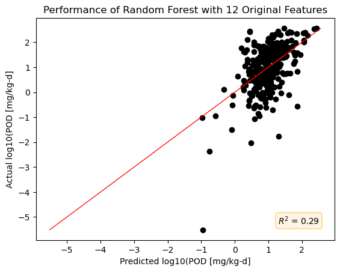

```python
title = 'Performance of Random Forest with {} Original Features'.format(count_features(results))
_ = plot_model_evaluation(**results, title=title)
```

```python
%%time

results = (
    random_forest_regression_pipeline(new_features, log10_pods))
```

```
Wall time: 725 ms
```

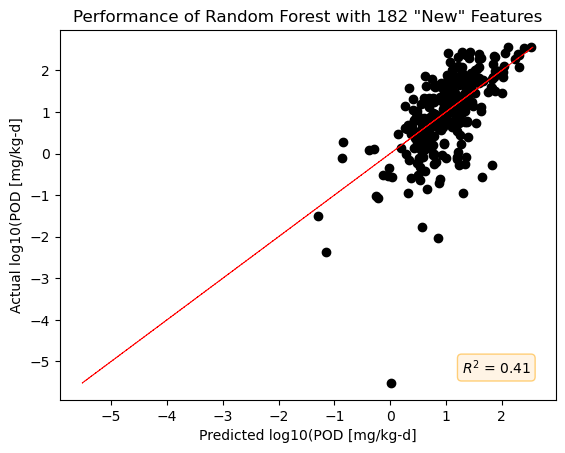

```python
title = 'Performance of Random Forest with {} "New" Features'.format(count_features(results))
_ = plot_model_evaluation(**results, title=title)
```

## Assess feature importances

`Permutation feature importance` is used to identify any irrelevant features in the new feature set. Permutation feature importance is defined as the mean decrease in a model's performance score (e.g., R2) when a given feature value is randomly shuffled *K* times. This approach has several advantages over the tree-based measure of feature importance that uses the mean decrease in impurity:

- Model agnostic and can be calculated many times with different permutations of the feature
- Unbiased with respect to high cardinality features (i.e., many unique values) vs. low cardinality features
- Can be computed on a held-out test or validation set, making it possible to highlight which features contribute the most to the generalization power of the model.

The cells below compute permutation feature importances across the new feature set, using R2 as the evaluation metric, and K = 30 permutations.

```python
%%time

metric = 'r2'
n_repeats = 30

permutation = permutation_importance(
    results['estimator'],
    results['X_test'],
    results['y_test'],
    scoring=metric,
    n_repeats=n_repeats,
    random_state=1,
    n_jobs=-1)
```

```
Wall time: 22.8 s
```

```python
feature_names = results['X_test'].columns

means = pd.Series(permutation['importances_mean'], index=feature_names)
stds = pd.Series(permutation['importances_std'], index=feature_names)

sorted_names = list(means.sort_values().index)

means, stds = means[sorted_names], stds[sorted_names]
```

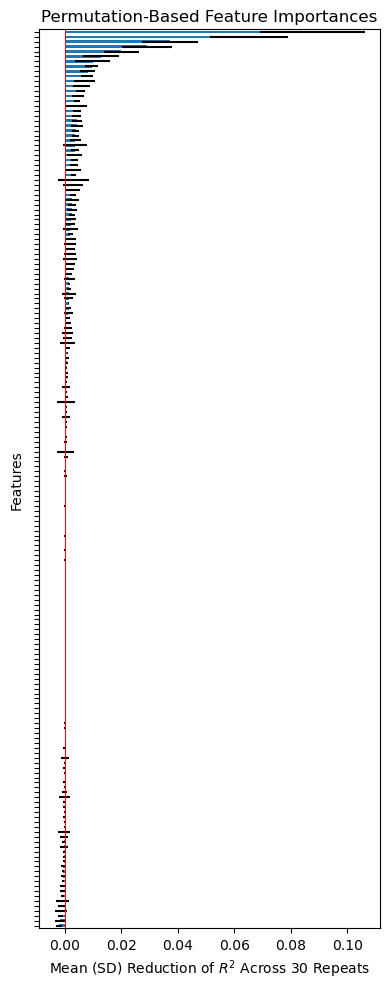

```python
figsize = (4., 10.)
title = 'Permutation-Based Feature Importances'
xlabel = 'Mean (SD) Reduction of $R^2$ Across ' + str(n_repeats) + ' Repeats'
ylabel = 'Features'

fig, ax = plt.subplots(figsize=figsize)

means.plot.barh(
    ax=ax,
    xerr=stds)

ax.set_title(title)
ax.set_xlabel(xlabel)
ax.set_yticklabels([])
ax.set_ylabel(ylabel)

ylim = ax.get_ylim()
ax.vlines(0., *ylim, color='red', linewidth=0.75)

fig.tight_layout()
```

## Drop Irrelevant Features and Re-train the model

We can drop the irrelevant features based on a specified threshold importance, and re-train the random forest. For now, use an importance threshold of 0.001 mean reduction of R2.

```python
thres_importance = 0.001
important_features_names = list(means.loc[means > thres_importance].index)
print('Drop', len(feature_names) - len(important_features_names), 'irrelevant features')
```

```
Drop 121 irrelevant features
```

```python
important_features_names
```

```
['EState_VSA5',
 'PEOE_VSA7',
 'SMR_VSA6',
 'Vapor Pressure',
 'EState_VSA10',
 'fr_N_O',
 'EState_VSA9',
 'MolMR',
 'SlogP_VSA3',
 'fr_sulfide',
 'VSA_EState1',
 'PEOE_VSA6',
 'MaxEStateIndex',
 'MinAbsEStateIndex',
 'Water Solubility',
 'VSA_EState2',
 'BCUT2D_MWLOW',
 'LogKow: Octanol-Water',
 'VSA_EState7',
 'SlogP_VSA11',
 'MinEStateIndex',
 'Kappa2',
 'BCUT2D_CHGHI',
 'LogKoa: Octanol-Air',
 'Index of Refraction',
 'EState_VSA6',
 'PEOE_VSA8',
 "Henry's Law",
 'Density',
 'VSA_EState5',
 'Melting Point',
 'PEOE_VSA11',
 'PEOE_VSA4',
 'NumHeteroatoms',
 'SMR_VSA3',
 'SlogP_VSA4',
 'Surface Tension',
 'FractionCSP3',
 'EState_VSA2',
 'PEOE_VSA1',
 'SlogP_VSA1',
 'Boiling Point',
 'VSA_EState3',
 'BCUT2D_LOGPLOW',
 'VSA_EState9',
 'fr_azo',
 'SlogP_VSA5',
 'BCUT2D_CHGLO',
 'fr_halogen',
 'BCUT2D_MRLOW',
 'SlogP_VSA10',
 'fr_NH0',
 'FpDensityMorgan2',
 'MinAbsPartialCharge',
 'SMR_VSA1',
 'MaxAbsPartialCharge',
 'Kappa3',
 'BCUT2D_MRHI',
 'VSA_EState10',
 'BCUT2D_LOGPHI',
 'BCUT2D_MWHI']
```

```python
%%time

important_features = new_features[important_features_names]

results = (
    random_forest_regression_pipeline(important_features, log10_pods))
```

```
Wall time: 399 ms
```

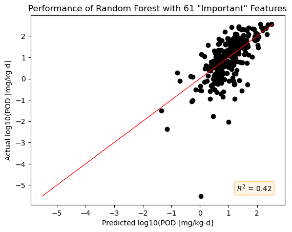

```python
N_features = str(len(results['X_test'].columns))
title = 'Performance of Random Forest with {} "Important" Features'.format(count_features(results))
_ = plot_model_evaluation(**results, title=title)
```

`NOTE`: There is currently an issue with persisting randomness even after setting a global seed. The results may change if the kernel is reset and the code is re-executed, which shows the degree of instability in the 1-fold train-test split. As a next step, I would like to identify the source of this randomness and fix it.

## Next steps

1. Implement 5- or 10-fold cross validation
2. Extend the pipeline to encompass additional machine learning models (e.g., SVM) and compare. The goal is to shortlist the most promising models and perhaps build an emsemble.
3. Implement more extensive hyperparameter tuning, e.g., via a grid search.